# Intro to text mining - Intro to NLP - 1

One should look for what is and not what he thinks should be. (Albert Einstein)

# Intro to NLP: Topic introduction

In this part of the course, we will cover the following concepts:

- NLP definition and use cases
- Text analysis terminology

# Chat question

- Here are some reviews of the movie *Doctor Strange in the Multiverse of Madness* that a data analyst wants to explore
- When dealing with text data like reviews, what **variables** should the analyst consider?
- How **long** might it take to analyze the data?

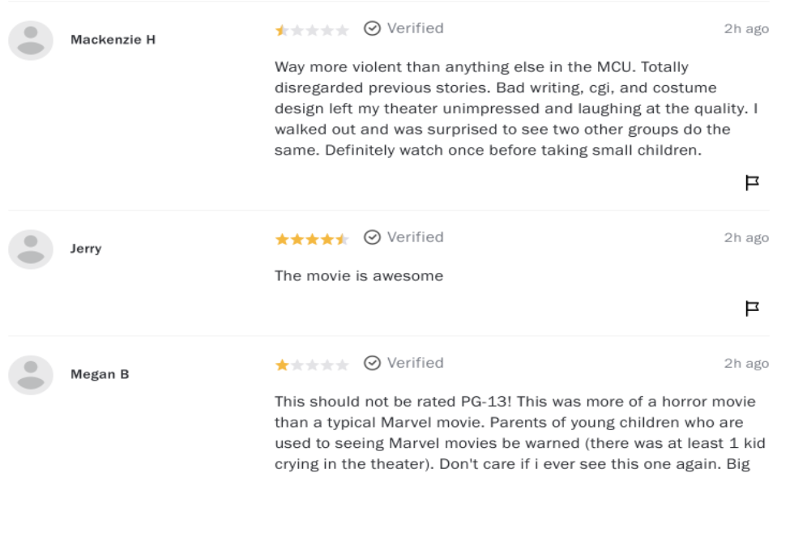

Source: [rotten_tomatoes](https://www.rottentomatoes.com/m/doctor_strange_in_the_multiverse_of_madness/reviews?type=verified_audience)

# Chat question

- Here is a graph built using a text-mining algorithm
- What **categories** define the text?
- What **insights** does this visualization allow you to see?

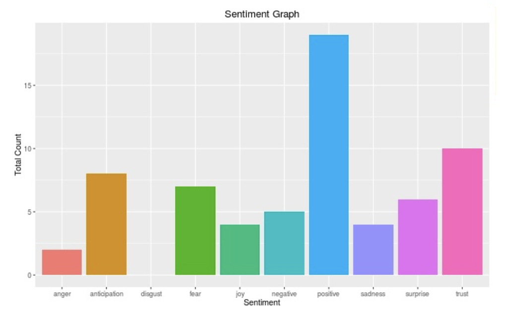

Source: [blog.journeyofanalytics](https://www.google.com/url?q=https://blog.journeyofanalytics.com/twitter-sentiment-analysis/&sa=D&source=editors&ust=1652361239859659&usg=AOvVaw2NzJejDpb48SJ1Gf_BhsKj)

# Module completion checklist

| Objective | Complete |
| --- | --- |
| Explain the concept of NLP and how it is used in industry |  |
| Discuss what a corpus is based on use cases |  |

# What are NLP and text analysis?

- **Natural Language Processing (NLP)** is a host of methods and disciplines, at the crossroad of :
  - data science
  - computational linguistics
  - artificial intelligence
- NLP’s main focus is *processing all forms of human language (spoken or written) and getting insightful information out of it*
- **Text analysis is a part of NLP** and we can use it for written text

# What is NLP used for?

- NLP is used for:
  - Generating human speech
  - Automating tasks like machine translation
  - Producing predictive models or detecting patterns in human language

Check out this [article](https://www.bloomberg.com/graphics/2020-democratic-presidential-candidate-policies/?utm_campaign=socialflow-organic&utm_medium=social&cmpid=socialflow-twitter-business&utm_content=business&utm_source=twitter) on an interesting application of NLP

# Why text analysis?

- Most of the information and knowledge in the world is stored as text

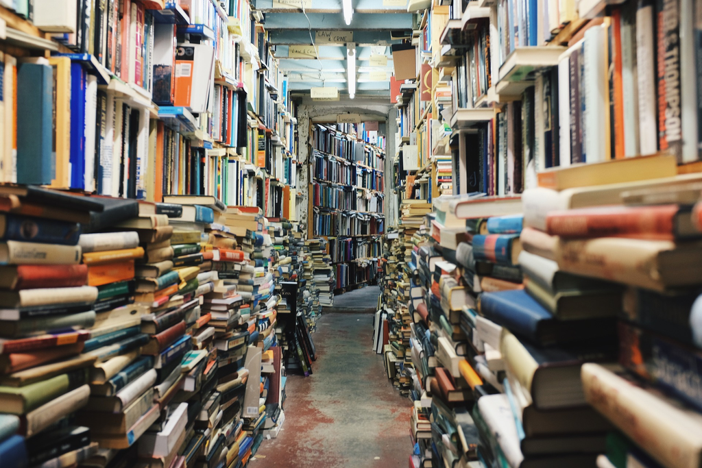

[figure not shown]

# Text analysis : What it is ?

- Text Analysis (TA) is an application of machine learning designed to derive meaningful information from unstructured textual data
- Text analysis solutions are deployed to efficiently process and analyze vast quantities of online data and documents, converting them into practical insights
- Text analysis can be employed to identify particular elements such as keywords, names, or corporate details within a massive volume of emails, or to classify feedback from surveys according to sentiment and subject matter

# Text analysis: flow and basic methods

- Text analysis tools range from the simplest to the most advanced
- Here’s an example of a flow of text analysis pipeline:

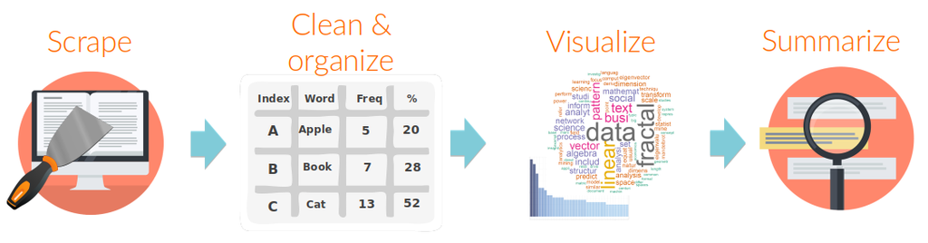

# Text analysis: more advanced methods

- Once you have scraped, cleaned, organized, visualized, and summarized data, more complex methods can be used

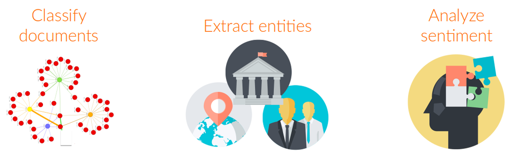

# Text analysis: use cases

| Field | Use case |
| --- | --- |
| Natural language processing | Discover patterns in speech; understand how human language works |
| Business | Help increase profits through analyzing product reviews; summarize and group reports, catalog documents |
| Psychology & Psychiatry | Analyze sentiments to detect and prevent dangerous social behavior |
| Network analysis | Augment network analysis to better understand how people interact within a group or react to a certain event |

# Module completion checklist

| Objective | Complete |
| --- | --- |
| Explain the concept of NLP and how it is used in industry | **✔** |
| Discuss what a corpus is based on use cases |  |

# Units of text data

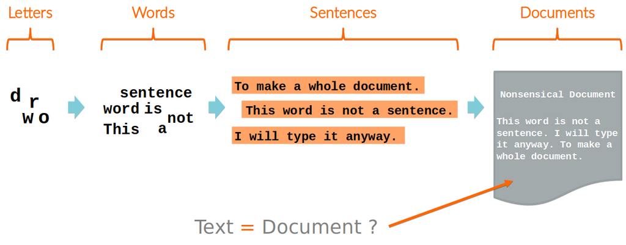

# Units of text data: corpus

[figure not shown]

# Units of text data: corpora

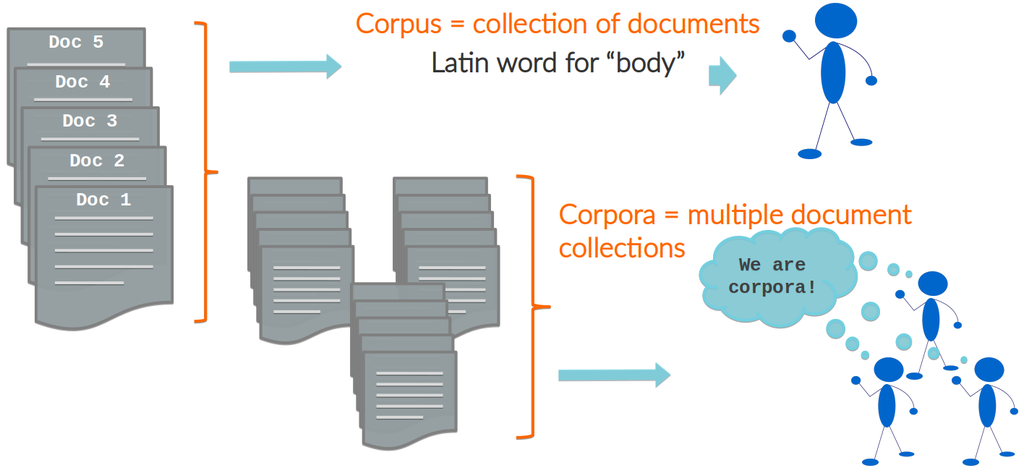

# Knowledge check

# Module completion checklist

| Objective | Complete |
| --- | --- |
| Explain the concept of NLP and how it is used in industry | **✔** |
| Discuss what a corpus is based on use cases | **✔** |

# Intro to NLP: Topic summary

In this part of the course, we have covered:

- NLP definition and use cases
- Text analysis terminology

# Congratulations on completing this module!